# Predicting Age Groups for Advertisement

2024-01-04

## Introduction and Problem

**Dataset:** National Health and Nutrition Health Survey 2013-2014 Age Prediction Subset

**Project Stakeholder:** Adult Diaper Company & their advertising team

**Problem:** Is there a way to direct advertisements of the product, adult diapers, so that it can reach the right age group?

## Question

**What is the predictive power of classification for predicting the likelihood of being categorized as a “senior” based on these health indicators?**

This gives us insights into how different health factors correlate with age. If the model has strong prediction power, it could be used by a company that makes products for seniors, such as adult diapers, to direct their advertisements to the right people.

## Dataset Features

This dataset has over 2000 observations and 7 features

- Age group: A binary variable of whether or not the respondent is classified as a senior (target variable)
- Age: Age as a continuous variable
- Gender
- Physical fitness: If the respondent engages in moderate or vigorous intensity sports, fitness, or recreational activities in the typical week. Binary variable: 1 = physically fit, 2 = no
- BMI: continuous variable
- Blood glucose after fasting
- Diabetes: Binary variable, 1 = diabetic, 2 = not diabetic
- Oral: glucose tolerance test for type 2 diabetes
- Insulin: Respondent’s blood insulin levels

## Exploratory Data Analysis

```
##   age_group         Age           Gender        Fitness_yn         BMI
##  Adult :1914   Min.   :12.0   Min.   :1.000   Min.   :1.000   Min.   :14.50
##  Senior: 364   1st Qu.:24.0   1st Qu.:1.000   1st Qu.:2.000   1st Qu.:22.80
##                Median :41.0   Median :2.000   Median :2.000   Median :26.80
##                Mean   :41.8   Mean   :1.511   Mean   :1.823   Mean   :27.96
##                3rd Qu.:58.0   3rd Qu.:2.000   3rd Qu.:2.000   3rd Qu.:31.20
##                Max.   :80.0   Max.   :2.000   Max.   :7.000   Max.   :70.10
##     Glucose        Diabetic_yn         Oral        Insulin
##  Min.   : 63.00   Min.   :1.000   Min.   : 40   Min.   :  0.14
##  1st Qu.: 91.00   1st Qu.:2.000   1st Qu.: 87   1st Qu.:  5.86
##  Median : 97.00   Median :2.000   Median :105   Median :  9.04
##  Mean   : 99.55   Mean   :2.016   Mean   :115   Mean   : 11.83
##  3rd Qu.:104.00   3rd Qu.:2.000   3rd Qu.:130   3rd Qu.: 14.44
##  Max.   :405.00   Max.   :3.000   Max.   :604   Max.   :102.29
```

## EDA cont.

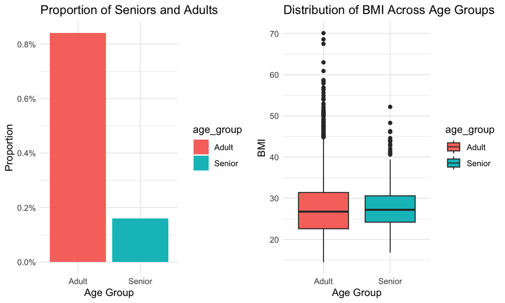

## EDA cont.

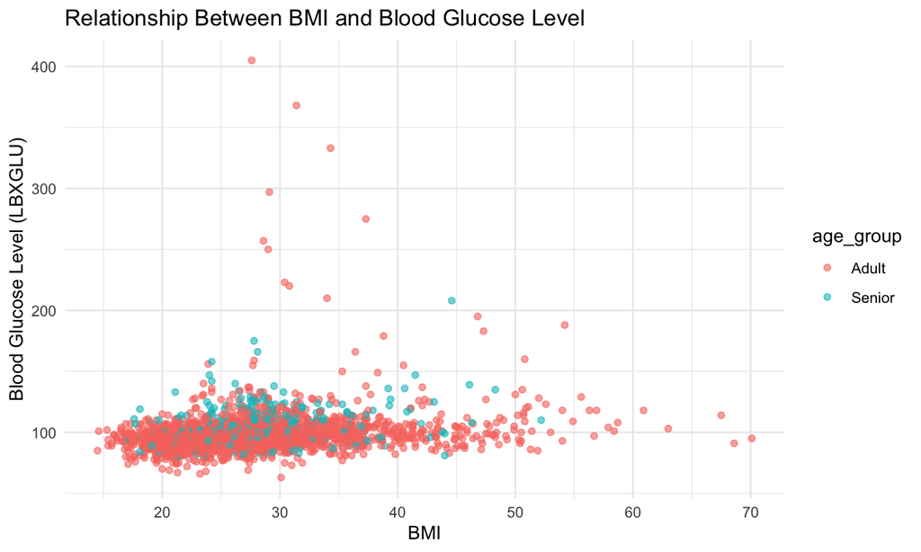

## EDA cont.

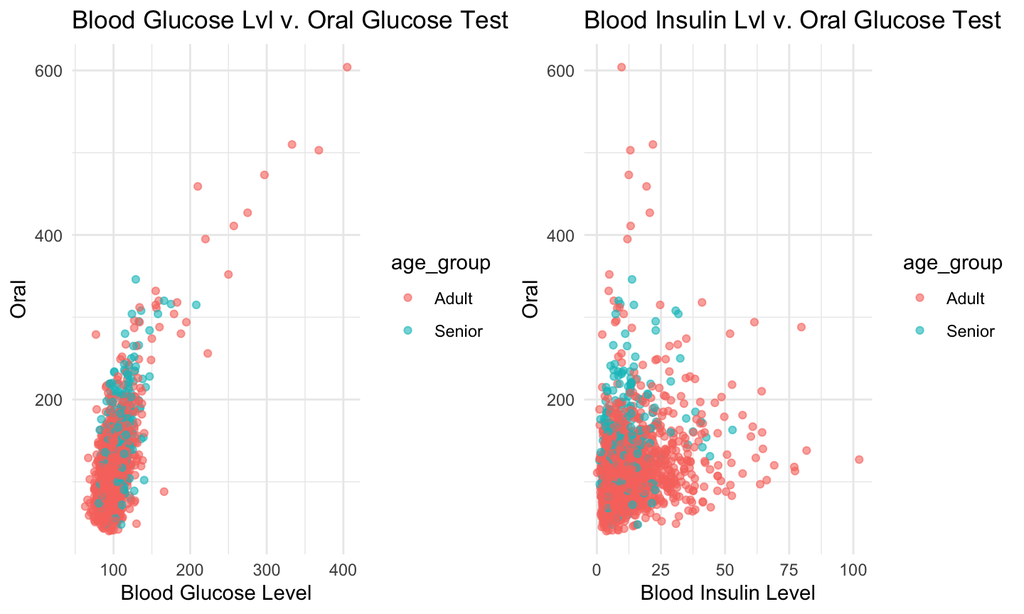

## EDA cont.

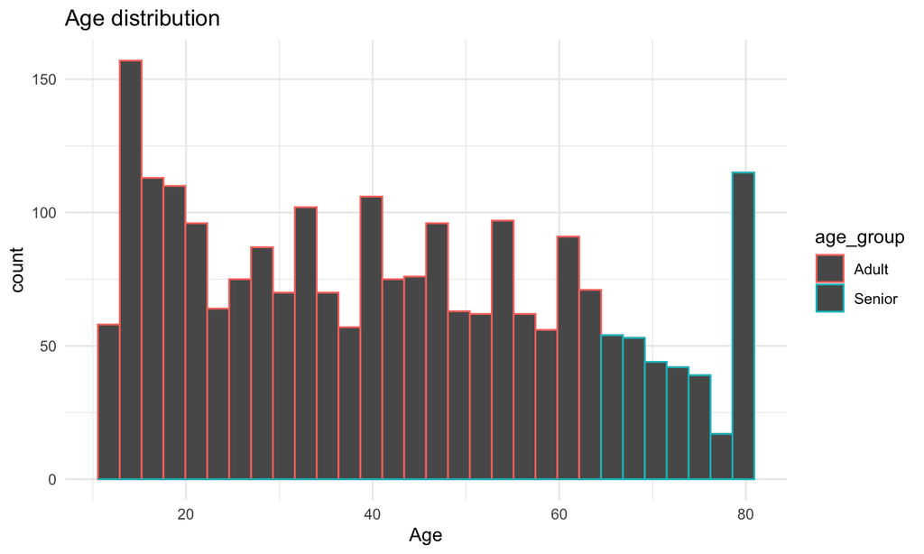

## EDA cont.

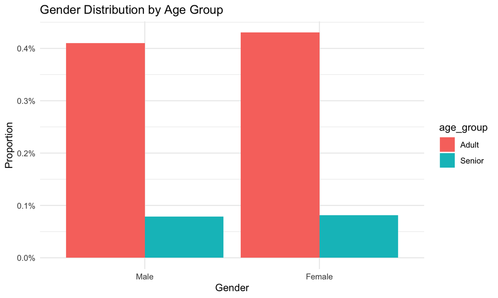

## EDA cont.

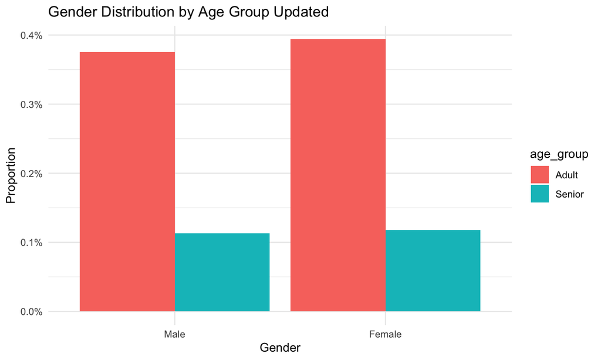

## Methods and Processing Plan

Random forest: ML algorithm that builds multiple decision trees during training and outputs the mode of the classes (classification) of individual trees for prediction

1. Readjusting threshold for ‘senior’ cut off
2. Normalizing and one hot encoding
3. Checking prevalence
4. Data partitioning

## Random Forest Final Model

```
##
## Call:
##  randomForest(formula = age_group_1 ~ ., data = training1)
##                Type of random forest: classification
##                      Number of trees: 500
## No. of variables tried at each split: 2
##
##         OOB estimate of  error rate: 22.32%
## Confusion matrix:
##      0  1 class.error
## 0 1177 51  0.04153094
## 1  305 62  0.83106267
```

## Model Evaluation

```
## [1] "Accuracy: 0.759882869692533"
```

```
## [1] "Sensitivity: 0.754884547069272"
```

```
## [1] "Specificity: 0.575"
```

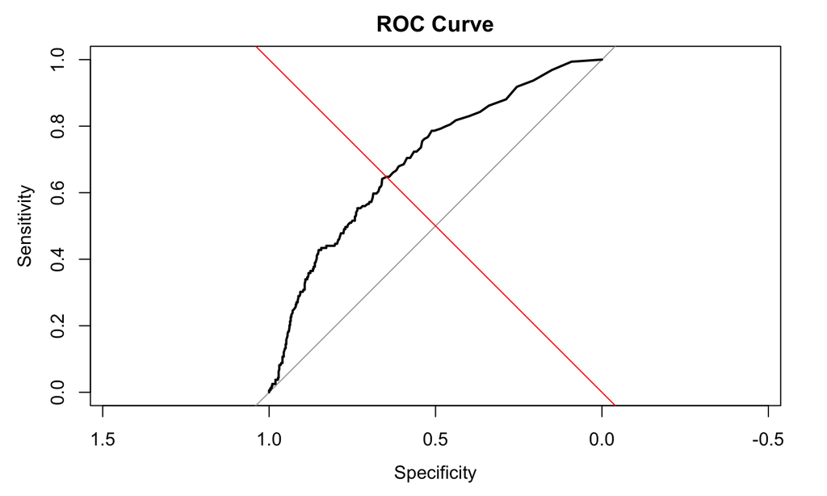

```
## Area under the curve: 0.6978
```

## Conclusion

- Constructing this model involved several trials and errors
- Adjusted many different thresholds 8-9 times
- Finally settled on model with the most consistency across all evaluation metrics
- Between our initial and final model, we were able to keep the AUC and accuracy score similar while increasing specificity and only slightly compromising sensitivity
- Ultimately, although trying our best to make a model that was a little more reliable, it’s average at best and there are a few more things we would consider to revise it further before confidently implementing it into our business

## Future Work

Limitations

- Only 7 features
- Information specifically on incontinence

Additional analysis

- Use more features by combining other data sets
- Try different predictive models